# R Notebook

## Introduction to the data

In this example, we will explore a data set that contains information on default payments, demographic factors, credit data, history of payment, and bill statements of credit card clients in Taiwan from April 2005 to September 2005.

This data set was obtained from the University of California, Irvine archives.

Source: https://archive.ics.uci.edu/ml/datasets/default+of+credit+card+clients

## Exploring the Data

First, Let us load the data into R and take an initial look at what we are dealing with. the str() function will allow us to compactly display the internal structure of our data set “credit1”. the summary() function will allow us to view a statistical summary of each of the variables we are dealing with.

```r
credit1 = read.csv("creditcard.csv")
str(credit1)
```

```
'data.frame':   30000 obs. of  25 variables:
 $ ID                        : int  1 2 3 4 5 6 7 8 9 10 ...
 $ LIMIT_BAL                 : num  20000 120000 90000 50000 50000 50000 500000 100000 140000 20000 ...
 $ SEX                       : int  2 2 2 2 1 1 1 2 2 1 ...
 $ EDUCATION                 : int  2 2 2 2 2 1 1 2 3 3 ...
 $ MARRIAGE                  : int  1 2 2 1 1 2 2 2 1 2 ...
 $ AGE                       : int  24 26 34 37 57 37 29 23 28 35 ...
 $ PAY_0                     : int  2 -1 0 0 -1 0 0 0 0 -2 ...
 $ PAY_2                     : int  2 2 0 0 0 0 0 -1 0 -2 ...
 $ PAY_3                     : int  -1 0 0 0 -1 0 0 -1 2 -2 ...
 $ PAY_4                     : int  -1 0 0 0 0 0 0 0 0 -2 ...
 $ PAY_5                     : int  -2 0 0 0 0 0 0 0 0 -1 ...
 $ PAY_6                     : int  -2 2 0 0 0 0 0 -1 0 -1 ...
 $ BILL_AMT1                 : num  3913 2682 29239 46990 8617 ...
 $ BILL_AMT2                 : num  3102 1725 14027 48233 5670 ...
 $ BILL_AMT3                 : num  689 2682 13559 49291 35835 ...
 $ BILL_AMT4                 : num  0 3272 14331 28314 20940 ...
 $ BILL_AMT5                 : num  0 3455 14948 28959 19146 ...
 $ BILL_AMT6                 : num  0 3261 15549 29547 19131 ...
 $ PAY_AMT1                  : num  0 0 1518 2000 2000 ...
 $ PAY_AMT2                  : num  689 1000 1500 2019 36681 ...
 $ PAY_AMT3                  : num  0 1000 1000 1200 10000 657 38000 0 432 0 ...
 $ PAY_AMT4                  : num  0 1000 1000 1100 9000 ...
 $ PAY_AMT5                  : num  0 0 1000 1069 689 ...
 $ PAY_AMT6                  : num  0 2000 5000 1000 679 ...
 $ default.payment.next.month: int  1 1 0 0 0 0 0 0 0 0 ...
```

```r
summary(credit1)
```

```
       ID          LIMIT_BAL            SEX          EDUCATION        MARRIAGE          AGE            PAY_0
 Min.   :    1   Min.   :  10000   Min.   :1.000   Min.   :0.000   Min.   :0.000   Min.   :21.00   Min.   :-2.0000
 1st Qu.: 7501   1st Qu.:  50000   1st Qu.:1.000   1st Qu.:1.000   1st Qu.:1.000   1st Qu.:28.00   1st Qu.:-1.0000
 Median :15000   Median : 140000   Median :2.000   Median :2.000   Median :2.000   Median :34.00   Median : 0.0000
 Mean   :15000   Mean   : 167484   Mean   :1.604   Mean   :1.853   Mean   :1.552   Mean   :35.49   Mean   :-0.0167
 3rd Qu.:22500   3rd Qu.: 240000   3rd Qu.:2.000   3rd Qu.:2.000   3rd Qu.:2.000   3rd Qu.:41.00   3rd Qu.: 0.0000
 Max.   :30000   Max.   :1000000   Max.   :2.000   Max.   :6.000   Max.   :3.000   Max.   :79.00   Max.   : 8.0000
     PAY_2             PAY_3             PAY_4             PAY_5             PAY_6           BILL_AMT1         BILL_AMT2
 Min.   :-2.0000   Min.   :-2.0000   Min.   :-2.0000   Min.   :-2.0000   Min.   :-2.0000   Min.   :-165580   Min.   :-69777
 1st Qu.:-1.0000   1st Qu.:-1.0000   1st Qu.:-1.0000   1st Qu.:-1.0000   1st Qu.:-1.0000   1st Qu.:   3559   1st Qu.:  2985
 Median : 0.0000   Median : 0.0000   Median : 0.0000   Median : 0.0000   Median : 0.0000   Median :  22382   Median : 21200
 Mean   :-0.1338   Mean   :-0.1662   Mean   :-0.2207   Mean   :-0.2662   Mean   :-0.2911   Mean   :  51223   Mean   : 49179
 3rd Qu.: 0.0000   3rd Qu.: 0.0000   3rd Qu.: 0.0000   3rd Qu.: 0.0000   3rd Qu.: 0.0000   3rd Qu.:  67091   3rd Qu.: 64006
 Max.   : 8.0000   Max.   : 8.0000   Max.   : 8.0000   Max.   : 8.0000   Max.   : 8.0000   Max.   : 964511   Max.   :983931
   BILL_AMT3         BILL_AMT4         BILL_AMT5        BILL_AMT6          PAY_AMT1         PAY_AMT2          PAY_AMT3
 Min.   :-157264   Min.   :-170000   Min.   :-81334   Min.   :-339603   Min.   :     0   Min.   :      0   Min.   :     0
 1st Qu.:   2666   1st Qu.:   2327   1st Qu.:  1763   1st Qu.:   1256   1st Qu.:  1000   1st Qu.:    833   1st Qu.:   390
 Median :  20089   Median :  19052   Median : 18105   Median :  17071   Median :  2100   Median :   2009   Median :  1800
 Mean   :  47013   Mean   :  43263   Mean   : 40311   Mean   :  38872   Mean   :  5664   Mean   :   5921   Mean   :  5226
 3rd Qu.:  60165   3rd Qu.:  54506   3rd Qu.: 50191   3rd Qu.:  49198   3rd Qu.:  5006   3rd Qu.:   5000   3rd Qu.:  4505
 Max.   :1664089   Max.   : 891586   Max.   :927171   Max.   : 961664   Max.   :873552   Max.   :1684259   Max.   :896040
    PAY_AMT4         PAY_AMT5           PAY_AMT6        default.payment.next.month
 Min.   :     0   Min.   :     0.0   Min.   :     0.0   Min.   :0.0000
 1st Qu.:   296   1st Qu.:   252.5   1st Qu.:   117.8   1st Qu.:0.0000
 Median :  1500   Median :  1500.0   Median :  1500.0   Median :0.0000
 Mean   :  4826   Mean   :  4799.4   Mean   :  5215.5   Mean   :0.2212
 3rd Qu.:  4013   3rd Qu.:  4031.5   3rd Qu.:  4000.0   3rd Qu.:0.0000
 Max.   :621000   Max.   :426529.0   Max.   :528666.0   Max.   :1.0000
```

The next step is to find out if we have any missing value, or if we will need to preform other types of data management.

```r
library(dplyr)
missing = credit1 %>% summarise_all(funs(sum(is.na(.))/n()))
missing
```

| ID | LIMIT_BAL | SEX | EDUCATION | MARRIAGE | AGE | PAY_0 | PAY_2 | PAY_3 | PAY_4 | PAY_5 | PAY_6 | BILL_AMT1 | BILL_AMT2 | BILL_AMT3 | BILL_AMT4 | BILL_AMT5 | BILL_AMT6 | PAY_AMT1 | PAY_AMT2 | PAY_AMT3 | PAY_AMT4 | PAY_AMT5 | PAY_AMT6 | default.payment.next.month |
| --- | --- | --- | --- | --- | --- | --- | --- | --- | --- | --- | --- | --- | --- | --- | --- | --- | --- | --- | --- | --- | --- | --- | --- | --- |
| 0 | 0 | 0 | 0 | 0 | 0 | 0 | 0 | 0 | 0 | 0 | 0 | 0 | 0 | 0 | 0 | 0 | 0 | 0 | 0 | 0 | 0 | 0 | 0 | 0 |

```r
# Lets remove the ID variable it is not needed
credit=credit1[,-1]
```

### Data Visualizations

Now lets create some data visualizations to learn more about the data. The first visualization will look at the percentage of clients who have not defaulted vs the those who have defaulted.

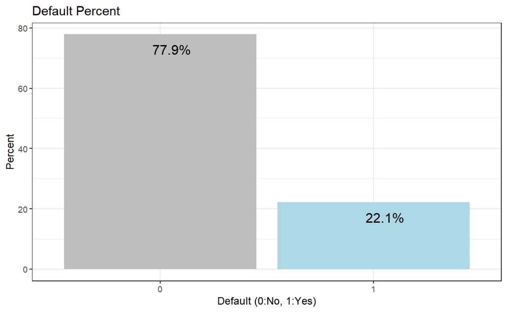

```r
library(ggplot2)
credit %>%
  group_by(default.payment.next.month) %>%
  summarise(Count = n())%>%
  mutate(percent = prop.table(Count)*100)%>%
  ggplot(aes(reorder(default.payment.next.month, -percent), percent), fill = default.payment.next.month)+
  geom_col(fill = c("grey", "light blue"))+
  geom_text(aes(label = sprintf("%.1f%%", percent)), hjust = 0.2, vjust = 2, size = 5)+
  theme_bw()+
  xlab("Default (0:No, 1:Yes)") + ylab("Percent") + ggtitle("Default Percent")
```

We see that 22.1% of clients have defaulted on their monthly payment and 77.9% of clients have not.

Visuals Continued

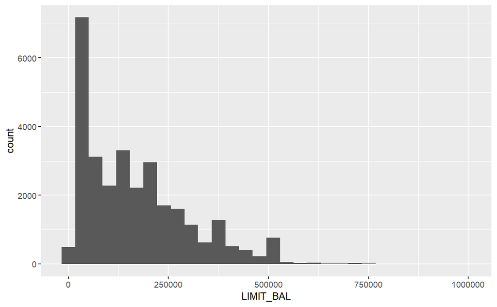

```r
library(ggplot2)
ggplot(credit, aes(x = LIMIT_BAL)) + geom_histogram()
```

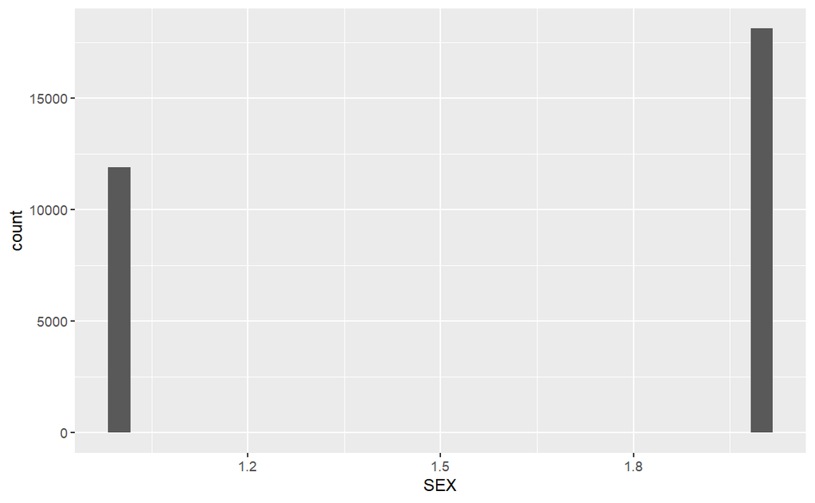

```r
ggplot(credit, aes(x = SEX)) + geom_histogram()
```

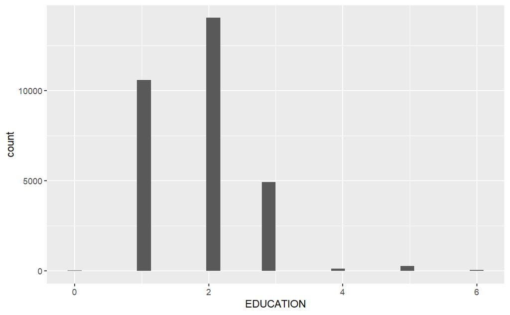

```r
ggplot(credit, aes(x = EDUCATION)) + geom_histogram()
```

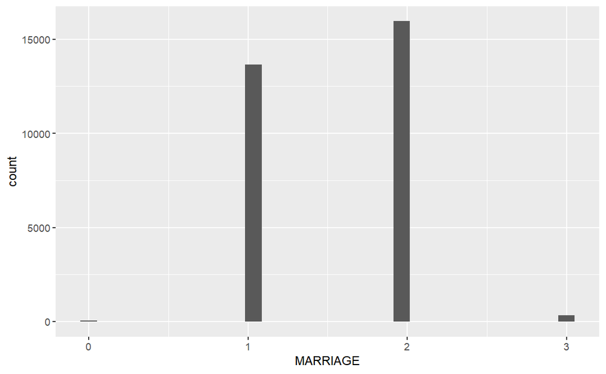

```r
ggplot(credit, aes(x = MARRIAGE)) + geom_histogram()
```

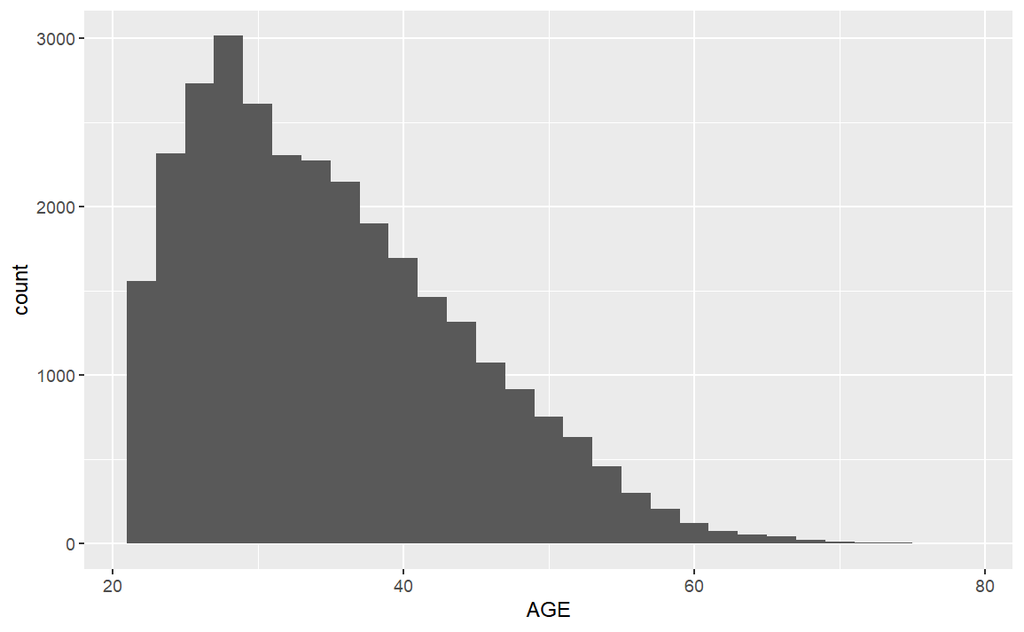

```r
ggplot(credit, aes(x = AGE)) + geom_histogram()
```

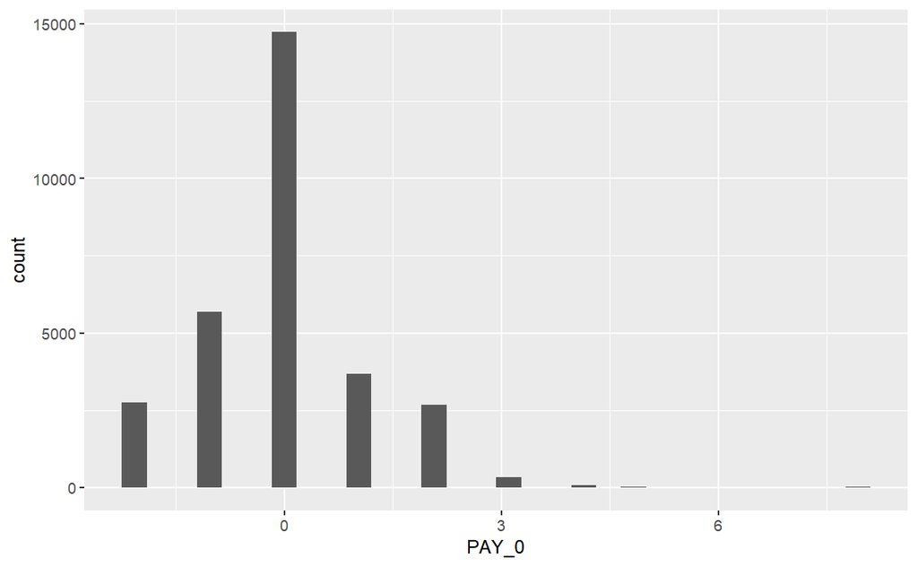

```r
ggplot(credit, aes(x = PAY_0)) + geom_histogram()
```

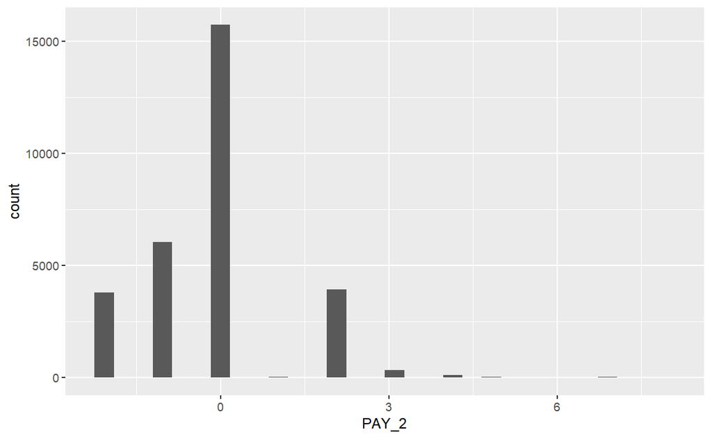

```r
ggplot(credit, aes(x = PAY_2)) + geom_histogram()
```

```r
table(credit$PAY_0)
```

```
   -2    -1     0     1     2     3     4     5     6     7     8
 2759  5686 14737  3688  2667   322    76    26    11     9    19
```

Limit_bal histogram - shows us the number of clients with a given credit balance in Taiwan Dollars. We can see that there is a large amount of clients with lower credit balances and a lower number of clients with higher credit amounts.

Age histogram - Shows us the number of credit card clients by age. We can see that the majority of clients are younger than 40 years of age.

### Data Management

Here we will preform some data management by combining variables that have a low number of observations with other variables that have low numbers of observations. We will also create some visuals for the new combined variables as well as turn some numeric variables into factors. This is so that we are able to run our logistical regression in the next steps.

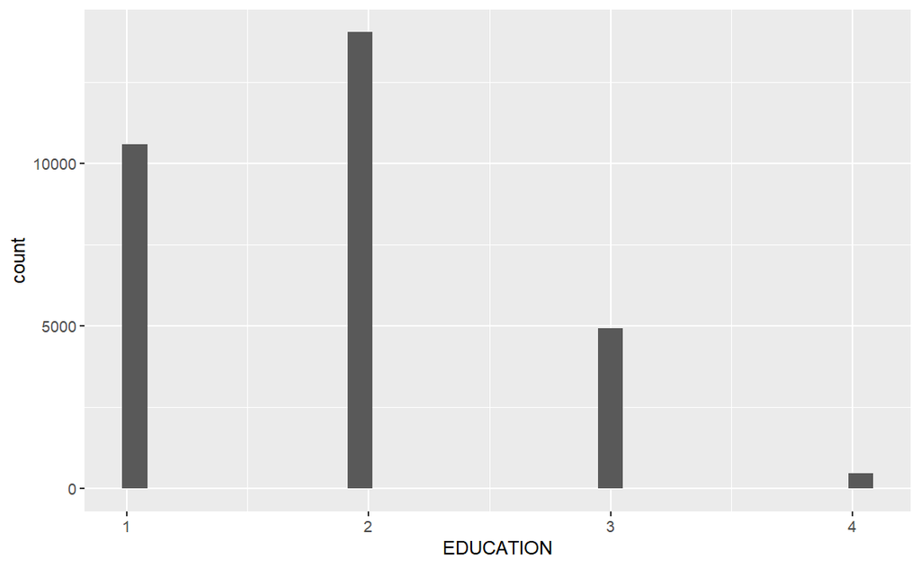

```r
# There are some catergories with very few observations. Let's group them together.
credit$EDUCATION[credit$EDUCATION == 0] = 4
credit$EDUCATION[credit$EDUCATION == 5] = 4
credit$EDUCATION[credit$EDUCATION == 6] = 4
credit$MARRIAGE[credit$MARRIAGE == 0] = 3

ggplot(credit, aes(x = EDUCATION)) + geom_histogram()
```

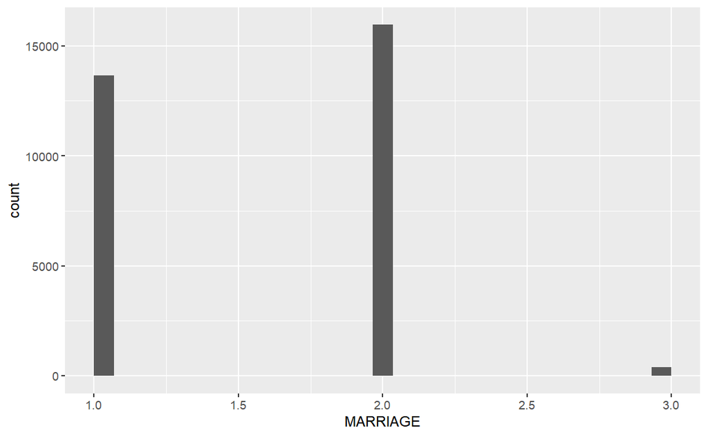

```r
ggplot(credit, aes(x = MARRIAGE)) + geom_histogram()
```

```r
# Make some numeric variables into factors
credit$default.payment.next.month=as.factor(credit$default.payment.next.month)
credit$SEX=as.factor(credit$SEX)
credit$EDUCATION=as.factor(credit$EDUCATION)
credit$MARRIAGE=as.factor(credit$MARRIAGE)
```

### Exploratory Data Analysis

Let us explore our data a little bit more. In this section we will run some simple EDA “Exploratory Data Analysis” by using ggplot to create some bar charts, box plot, and violin charts. This will help us better understand our data.

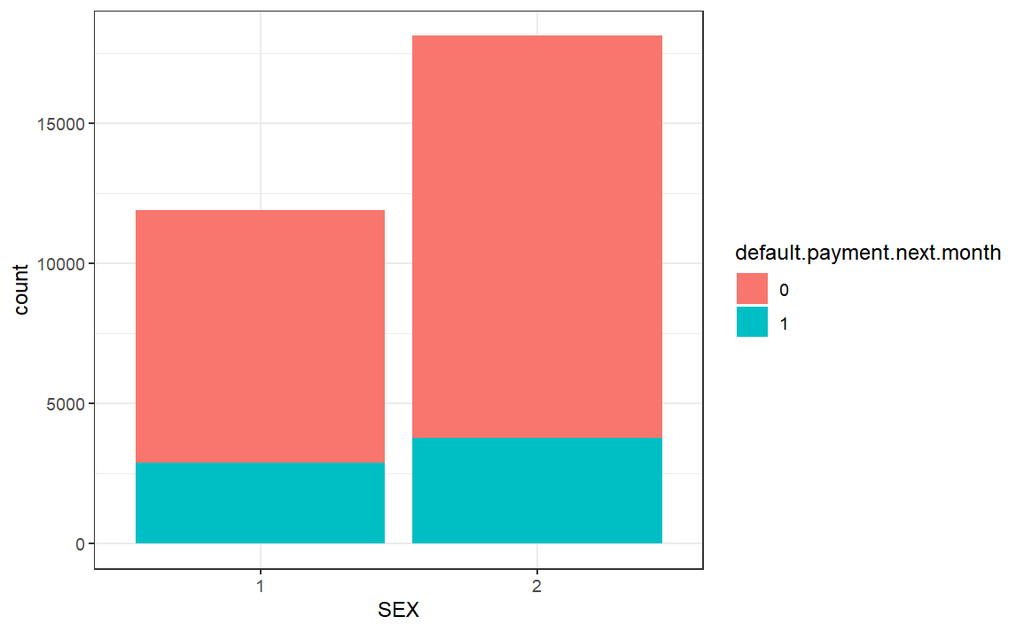

```r
# Some simple EDA
# Default against catergorial variables
ggplot(credit, aes(x=SEX,fill=default.payment.next.month))+ geom_bar()+ theme_bw()
```

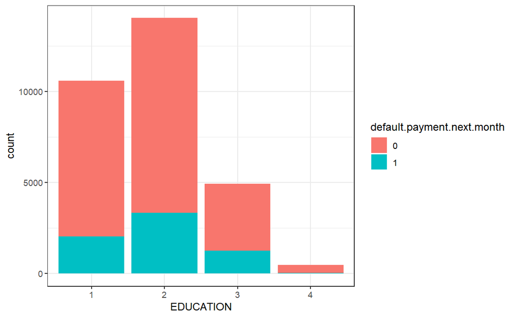

```r
ggplot(credit, aes(x=EDUCATION,fill=default.payment.next.month))+ geom_bar()+theme_bw()
```

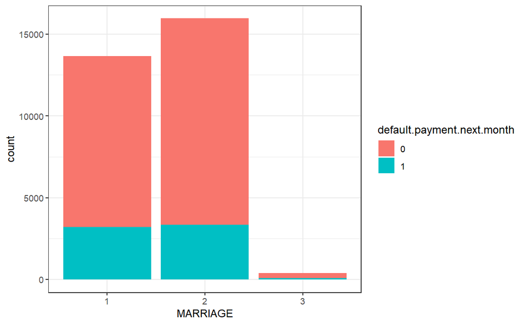

```r
ggplot(credit, aes(x=MARRIAGE,fill=default.payment.next.month))+ geom_bar()+theme_bw()
```

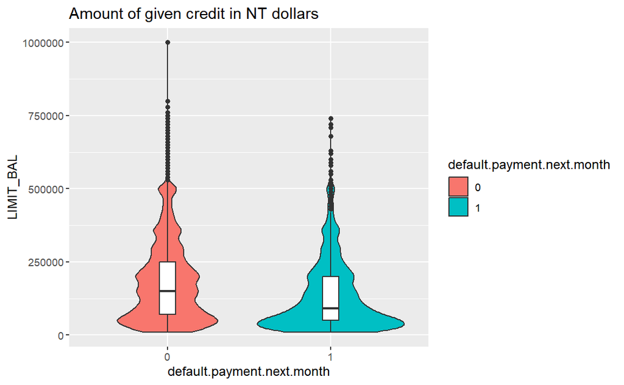

```r
# Default against numeric variables
ggplot(credit, aes(x=default.payment.next.month, y=LIMIT_BAL, fill=default.payment.next.month)) + geom_violin()+
  geom_boxplot(width=0.1, fill="white") + labs(title="Amount of given credit in NT dollars")
```

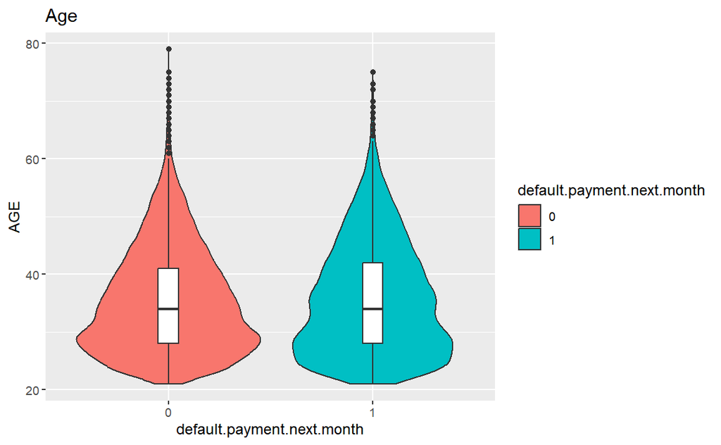

```r
ggplot(credit, aes(x=default.payment.next.month, y=AGE, fill=default.payment.next.month)) + geom_violin()+
  geom_boxplot(width=0.1, fill="white") + labs(title="Age")
```

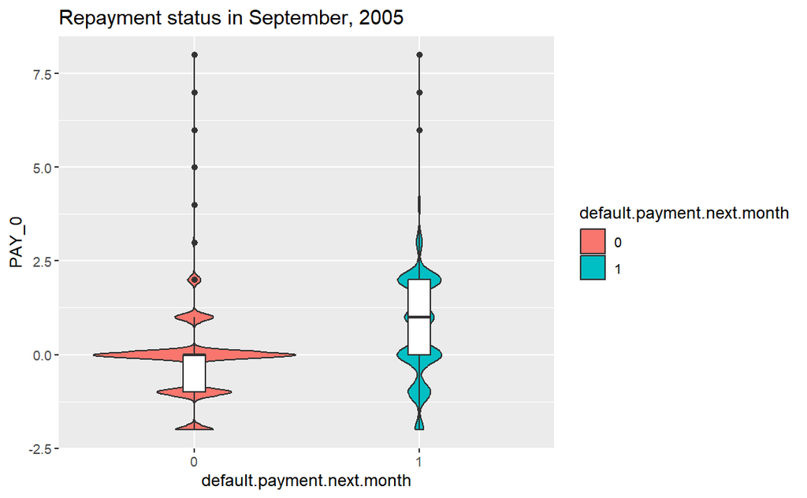

```r
ggplot(credit, aes(x=default.payment.next.month, y=PAY_0, fill=default.payment.next.month)) + geom_violin()+
  geom_boxplot(width=0.1, fill="white") + labs(title="Repayment status in September, 2005")
```

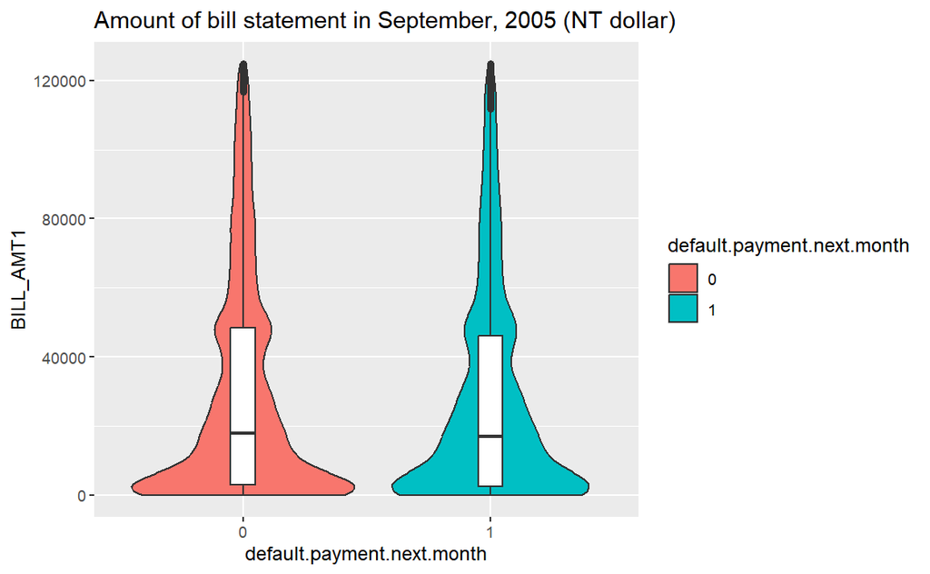

```r
ggplot(credit, aes(x=default.payment.next.month, y=BILL_AMT1, fill=default.payment.next.month)) + geom_violin()+
  geom_boxplot(width=0.1, fill="white") + labs(title="Amount of bill statement in September, 2005 (NT dollar)")+
  ylim(0,125000)
```

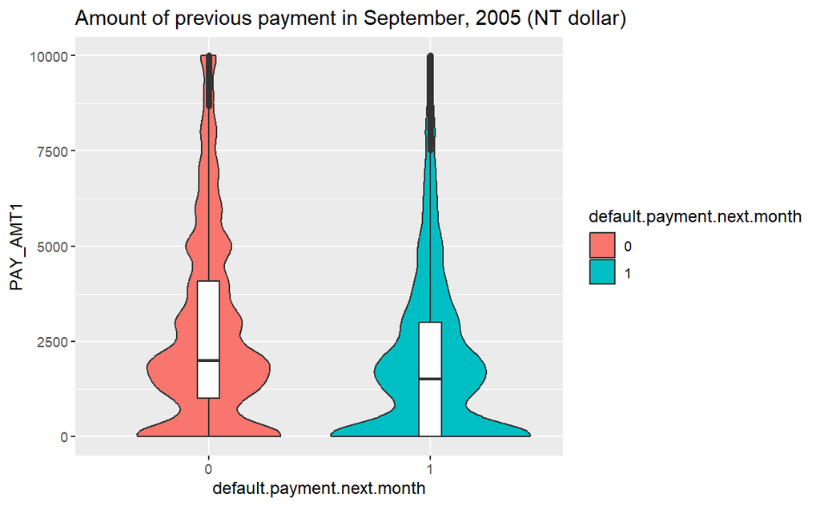

```r
ggplot(credit, aes(x=default.payment.next.month, y=PAY_AMT1, fill=default.payment.next.month)) + geom_violin()+
  geom_boxplot(width=0.1, fill="white") + labs(title="Amount of previous payment in September, 2005 (NT dollar)")+
  ylim(0,10000)
```

In the bar charts there are two components the first being the variable that we are observing which is on the X - axis, and the second is if the client defaulted on their monthly payment where the salmon color means no, and the blue means yes.

If we take a look at the education bar chart where, 1 = graduate school, 2 = university, 3 = high school, and 4 = other. We can see that the majority of the credit card clients have a university degree or higher. We can also see the split between clients who did not default on their payment an clients who did default on their payment relative to the category the client falls under.

If we look at the violin and box charts. The first thing we notice is that we have separated the clients who have defaulted on their credit card payment from those who did not. We did this to compare the two groups to each other.

In the violin and box charts, like the bar charts, are made up of multiple components. This time our variable we are observing is on the Y - axis. The first part of our visual insights is the violin, or blob looking portion of the chart. This part of the chart allows us to see the density of observations as we move up from 0. The wider the blob the greater the number of observations, the narrower the blob the lesser the number of observations. The second part, is the box plot which allows us to see the median, upper quartile, lower quartile, and both upper and lower extremes. The last part is if the client defaulted on their monthly payment where the salmon color means no, and the blue means yes.

Lets take a look at the characteristics of the clients who did not default on their payment compared to those of the clients who did using our limit_bal variable. The first thing to make note of is that the group that defaulted has a wider base, letting us know that there was a large amount of clients who defaulted with lower credit limits available to them. The second thing we notice is that the group that did not default has more clients with larger credit limits and an outlier with a really high credit limit compared to the default group.

### The Logistical Regression

Now we will run a logistical regression

```r
# Logistic model
logit.1 = glm(default.payment.next.month~., data=credit, family="binomial")
summary(logit.1)
```

```
Call:
glm(formula = default.payment.next.month ~ ., family = "binomial",
    data = credit)

Coefficients:
              Estimate Std. Error z value Pr(>|z|)
(Intercept) -9.945e-01  8.651e-02 -11.495  < 2e-16 ***
LIMIT_BAL   -7.133e-07  1.577e-07  -4.522 6.11e-06 ***
SEX2        -1.130e-01  3.073e-02  -3.677 0.000236 ***
EDUCATION2  -8.452e-02  3.557e-02  -2.376 0.017506 *
EDUCATION3  -1.130e-01  4.760e-02  -2.375 0.017556 *
EDUCATION4  -1.162e+00  1.884e-01  -6.169 6.88e-10 ***
MARRIAGE2   -1.878e-01  3.463e-02  -5.422 5.90e-08 ***
MARRIAGE3   -1.932e-01  1.319e-01  -1.464 0.143112
AGE          5.635e-03  1.859e-03   3.031 0.002441 **
PAY_0        5.775e-01  1.771e-02  32.610  < 2e-16 ***
PAY_2        8.112e-02  2.020e-02   4.017 5.90e-05 ***
PAY_3        7.107e-02  2.261e-02   3.143 0.001669 **
PAY_4        2.289e-02  2.500e-02   0.915 0.359938
PAY_5        3.418e-02  2.689e-02   1.271 0.203700
PAY_6        7.179e-03  2.215e-02   0.324 0.745886
BILL_AMT1   -5.495e-06  1.137e-06  -4.831 1.36e-06 ***
BILL_AMT2    2.394e-06  1.505e-06   1.591 0.111683
BILL_AMT3    1.396e-06  1.324e-06   1.054 0.291694
BILL_AMT4   -1.765e-07  1.352e-06  -0.131 0.896140
BILL_AMT5    7.716e-07  1.523e-06   0.507 0.612305
BILL_AMT6    1.770e-07  1.198e-06   0.148 0.882525
PAY_AMT1    -1.368e-05  2.308e-06  -5.928 3.07e-09 ***
PAY_AMT2    -9.532e-06  2.089e-06  -4.563 5.03e-06 ***
PAY_AMT3    -2.622e-06  1.719e-06  -1.525 0.127151
PAY_AMT4    -4.067e-06  1.786e-06  -2.278 0.022756 *
PAY_AMT5    -3.142e-06  1.779e-06  -1.766 0.077325 .
PAY_AMT6    -2.069e-06  1.297e-06  -1.596 0.110534
---
Signif. codes:  0 ‘***’ 0.001 ‘**’ 0.01 ‘*’ 0.05 ‘.’ 0.1 ‘ ’ 1

(Dispersion parameter for binomial family taken to be 1)

    Null deviance: 31705  on 29999  degrees of freedom
Residual deviance: 27840  on 29973  degrees of freedom
AIC: 27894

Number of Fisher Scoring iterations: 6
```

### Predicting Credit Default Rates

```r
pred = predict(logit.1, type = "response", credit)
summary(pred)
```

```
   Min. 1st Qu.  Median    Mean 3rd Qu.    Max.
 0.0000  0.1177  0.1941  0.2212  0.2587  0.9936
```

```r
str(pred)
```

```
 Named num [1:30000] 0.512 0.149 0.197 0.244 0.135 ...
 - attr(*, "names")= chr [1:30000] "1" "2" "3" "4" ...
```